# Project 2.1: Data Cleanup

### Structure of Report

1. Business and Data Understanding

a. Goal of project  
b. Dataset overview  
b. Key decision

2. Data Cleanup

a. Building the Training Set  
b. Dealing with Outliers

3. Analysis, Modeling, and Validation

a. Analysis  
b. Modeling  
c. Validation

4. Conclusions

## 1. Business and Data Understanding

#### a. Goal of project

  > We need to find out which city should be a new place to open new pet store, based on yearly sales.
- What data is needed to inform those decisions?

  > We need consider some predictor variables such as `Land Area`, `Population Density`, and `Total Families` in order to predict revenues for stores expected opening at cities. After that we will decide which city will be choosen to open store.

## 2. Data Cleanup

### a. Building the Training Set

#### Dataset 1 `p2-2010-pawdacity-monthly-sales-p2-2010-pawdacity-monthly-sales.csv`:

|  | NAME | ADDRESS | CITY | STATE | ZIP | January | February | March | April | May | June | July | August | September | October | November | December |
| --- | --- | --- | --- | --- | --- | --- | --- | --- | --- | --- | --- | --- | --- | --- | --- | --- | --- |
| 0 | Pawdacity | 509 Fort St # A | Buffalo | WY | 82834 | 16200 | 13392 | 14688 | 17064 | 18360 | 14040 | 12960 | 19224 | 15984 | 13392 | 13176 | 16848 |
| 1 | Pawdacity | 601 SE Wyoming Blvd Unit 252 | Casper | WY | 82609 | 29160 | 21600 | 27000 | 27648 | 29160 | 27216 | 25488 | 25704 | 22896 | 25272 | 28944 | 27648 |
| 2 | Pawdacity | 3769 E Lincolnway | Cheyenne | WY | 82001 | 79920 | 70632 | 79056 | 77544 | 73656 | 77976 | 73872 | 77544 | 78516 | 74520 | 74736 | 79920 |
| 3 | Pawdacity | 2625 Big Horn Ave | Cody | WY | 82414 | 19440 | 15984 | 19008 | 18144 | 16632 | 17496 | 18792 | 20304 | 19224 | 18144 | 18576 | 16632 |
| 4 | Pawdacity | 123 S 2nd St | Douglas | WY | 82633 | 16200 | 13392 | 14688 | 17064 | 18360 | 14040 | 12960 | 19224 | 15984 | 29808 | 17496 | 18792 |

> We need to check Dataset `p2-2010-pawdacity-monthly-sales-p2-2010-pawdacity-monthly-sales.csv` to ensure the data type suitable to . In addition we need to create a new column `Total_Sale` in order to make analysis based on predicted yearly sales

#### Dataset 2 `p2-partially-parsed-wy-web-scrape.csv`:

|  | City\|County | 2014 Estimate | 2010 Census | 2000 Census |
| --- | --- | --- | --- | --- |
| 0 | Afton\|Lincoln | <td>1,968</td> | <td>1,911</td> | <td>1,818</td> |
| 1 | Albin\|Laramie | <td>185</td> | <td>181</td> | <td>120</td> |
| 2 | Alpine\|Lincoln | <td>845</td> | <td>828</td> | <td>550</td> |
| 3 | Baggs\|Carbon | <td>439</td> | <td>440</td> | <td>348</td> |
| 4 | Bairoil\|Sweetwater | <td>107</td> | <td>106</td> | <td>97</td> |

> Dataset `p2-partially-parsed-wy-web-scrape.csv` has some obvious problems with data, we need to parse column `City|County` into `City` and `County`. All of characters such as `<td>` and `</td>` or `,` need to be delete. Data type need to be suitable to make analysis.

#### Dataset 3 `p2-wy-demographic-data.csv`

|  | City | County | Land Area | Households with Under 18 | Population Density | Total Families |
| --- | --- | --- | --- | --- | --- | --- |
| 0 | Laramie | Albany | 2513.745235 | 2075 | 5.19 | 4668.93 |
| 1 | Rock River | Albany | 200.444000 | 165 | 0.41 | 372.30 |
| 2 | Basin | Big Horn | 543.951304 | 250 | 0.66 | 566.43 |
| 3 | Burlington | Big Horn | 137.646214 | 63 | 0.17 | 143.34 |
| 4 | Byron | Big Horn | 252.489592 | 116 | 0.31 | 262.93 |

> Dataset 3, generally is good. But we still need to make all data in exact types in order to make analysis easily and no mistakes occurred

After processing data at the first step, we will have a raw dataset with the `sum` and `average` of all numeric columns like:

|  | sum | average |
| --- | --- | --- |
| Land Area | 33071.38 | 3006.49 |
| Households with Under 18 | 34064.00 | 3096.73 |
| Population Density | 62.80 | 5.71 |
| Total Families | 62652.79 | 5695.71 |
| Census Population | 213862.00 | 19442.00 |
| Total Pawdacity Sales | 3773304.00 | 343027.64 |

### b. Dealing with Outliers

The pairplot with kind="reg" following shows the linear relationship between variables in the dataset. With the plot we can see how good is the linear relationship between the predictor variables and target variable. Also, how is the outliers in the dataset can be seen in the plot. The target variable is `Total Pawdacity Sales` and predictor variables are `Land Area`,`Households with Under 18`,`Population Density`, `Total Families`, `Census Population`

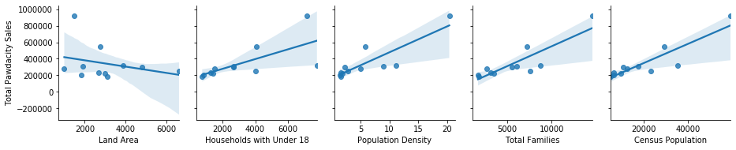

> We use the method IQR to indentify the outlier. We have:

> ```
>                -  Q1 = df.quantile(0.25)
>                -  Q3 = df.quantile(0.75)
>                - IQR = Q3-Q1
> ```

> - So the upper bound = Q3 + 1.5*IQR
> - And the low bound = Q1 - 1.5*IQR

So the point outside the upper bound and lower bound will be considered as outliers. Using such method we will have outliers like following:

|  | NAME | City | County | ADDRESS | Land Area | Households with Under 18 | Population Density | Total Families | Census Population | Total Pawdacity Sales |
| --- | --- | --- | --- | --- | --- | --- | --- | --- | --- | --- |
| 2 | Pawdacity | Cheyenne | Laramie | 3769 E Lincolnway | 1500.178400 | 7158 | 20.34 | 14612.64 | 59466 | 917892 |
| 6 | Pawdacity | Gillette | Campbell | 200 E Lakeway Rd | 2748.852900 | 4052 | 5.80 | 7189.43 | 29087 | 543132 |
| 9 | Pawdacity | Rock Springs | Sweetwater | 2706 Commercial Way | 6620.201916 | 4022 | 2.78 | 7572.18 | 23036 | 253584 |

The problem is that here we dealt with a very small dataset, when we delete or remove all outliers, the dataset will be changed alot and maybe cause a bad analysis as well as a wrong prediction. So we need to consider only one outliner need to be remove or impute.

All in all, `Gillette` seems to be outside the regression model of dataset and the relationship between it and other values is unclear. Although `Cheyenne` and `Rock Springs` are also outliers because in some columns its values are not normal, but in general, its relation with other variables can be explained. So we will impute `Gillette` out of dataset.

We use Alteryx to clean the data. The workflow is following:

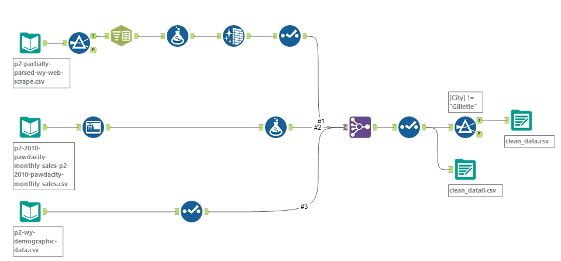

## 3. Analysis, Modeling, and Validation

### a. Analysis

- There are some conditions from manager for choosing a city to open new store:
  - The new store should be located in a new city. That means there should be no existing stores in the new city.
  - The total sales for the entire competition in the new city should be less than \$500,000
  - The new city where you want to build your new store must have a population over 4,000 people (based upon the 2014 US Census estimate).
  - The predicted yearly sales must be over $200,000.
- At first, we need to find important predictor variables to use in the regression model with `Total Pawdacity Sales` as the target variable. The following is the heatmap to see the relationships between two variables.

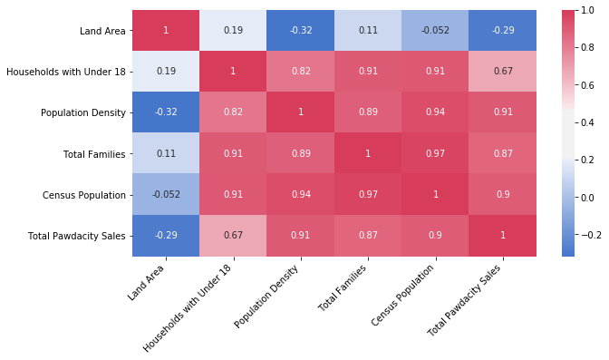

### b. Modeling

After choosing predictor variables to the model. We will run Alteryx and have a regression liner:

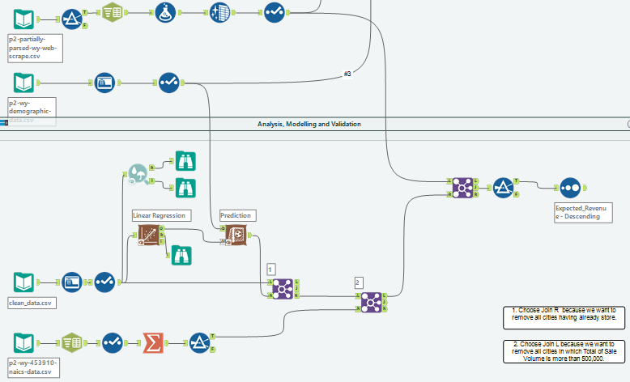

- The linear regression will be:

> `[Total Pawdacity Sales]` = 197,330 – 48.42 *`[Land Area]` + 49.14* `[Total Families]`

### c. Validation

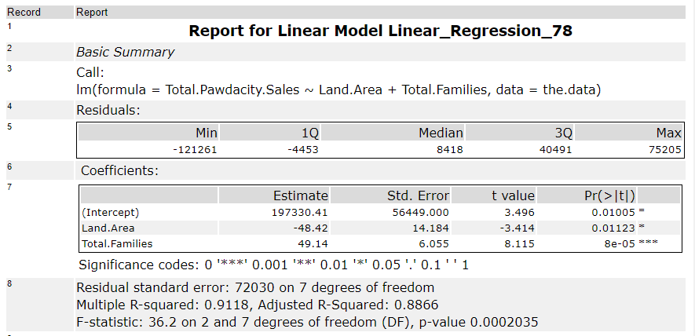

> With the report, we can see that linear regression is quite good to predict the revenue of expected stores because all of predictor variables are statistical significant with `p_value` < 0.05. In addition `Adjusted R-Square` = 0.8866 shows thatthe regression model is also good.

## 4.Conclusion:

|  | City | County | Land.Area | Population.Density | Households.with.Under.18 | Total.Families | Census Population | 2014 Estimate | Sum_Sale Volume of Rivals | Expected_Revenue |
| --- | --- | --- | --- | --- | --- | --- | --- | --- | --- | --- |
| 0 | Laramie | Albany | 2513.745235 | 5.19 | 2075 | 4668.93 | 30816 | 32081 | 76000.0 | 305013.881671 |
| 1 | Jackson | Teton | 1757.659200 | 2.36 | 1078 | 2313.08 | 9577 | 10449 | 182000.0 | 225870.823600 |
| 2 | Lander | Fremont | 3346.809340 | 1.63 | 1870 | 3876.81 | 7487 | 7642 | 152197.0 | 225751.400203 |
| 3 | Green River | Sweetwater | 3477.361206 | 1.46 | 2113 | 3977.40 | 12515 | 12630 | NaN | 224372.001382 |
| 4 | Worland | Washakie | 1294.105755 | 2.18 | 595 | 1364.32 | 5487 | 5366 | 169000.0 | 201700.325919 |
| 5 | Rawlins | Carbon | 5322.661628 | 1.32 | 1307 | 2722.43 | 9259 | 9227 | NaN | 73349.567407 |

#### Recomendation:

> So the city which should be chosen to open new store is **Laramie in Albany** with population based on `2014 Estimate` of 32,081 and the highest `Expected_Revenue` of \$305,013.88.